# KNN Fifa22 SageMaker

[figure not shown]

## Table of Content

1. Data and goals
   1. Goals
   2. Data Source
   3. Initial Data Analysis
2. Cleaning & Preprocessing
   1. Column Inspection
   2. Target Column
   3. Nulls
   4. Outliers
3. Amazon Sagemaker - KNN
   1. Set Up
   2. Training
   3. Testing
4. Hyperparameter Tuning
   1. Set Up
   2. Tuning
   3. More Predictions
   4. PCA
5. Final Conclusion

## Dataset & Goals

### Goals

The objective of this project is to be able to make predictions on what a players best position is on the field based on their attributes in the Fifa dataset. Each player will have a set of skills and defining characteristics. Based on these inputs I will create an ML model that can decide where they should play.  
I beleive a tool like this could be useful to management staff when assessing new players. They will have the data related to their skill set and features like height, age etc and from this can decide where they should play. This can be especially useful when looking for now talent,discussing with a player who wants to be a stiker but your data would suggest otherwise and you play them in a more appropriate position or if dealing with an ageing player who usually goes in midfield but as their speed and fitness decreases the model might show they are better suited to a defending role.

### Data Source

The data set used was taken from kagle, a great source for data science entusiasts to explore new data, enhance their skills and have some fun. The Fifa 22 Plater data set can be found [here](https://www.kaggle.com/datasets/stefanoleone992/fifa-22-complete-player-dataset). The datasets provided include the players data for the Career Mode from FIFA 15 to FIFA 22 ("players_22.csv"). This is really cool because you can concaternate the data set from the past 7 years, monitor player progression or young prospects who never quite made it and evaluate the "potential" Fifa applied to them at various years. For the sake of this experiment I am focusing on the 2022 Player Data Set and the goal is to be able to create a K-Nearest Neighbor model that can accurately predict the players position. This project was done using Python, so lets take a look at the dataset using Pandas.

### Initial Data Analysis

```python
import pandas as pd
import numpy as np
fifa = pd.read_csv("../Data/fifa22.csv",low_memory=False)
print("Lets look at some of the data to get an understanding of it")
fifa.head(3)
```

```
Lets look at some of the data to get an understanding of it
```

|  | sofifa_id | player_url | short_name | long_name | player_positions | overall | potential | value_eur | wage_eur | age | ... | lcb | cb | rcb | rb | gk | player_face_url | club_logo_url | club_flag_url | nation_logo_url | nation_flag_url |
| --- | --- | --- | --- | --- | --- | --- | --- | --- | --- | --- | --- | --- | --- | --- | --- | --- | --- | --- | --- | --- | --- |
| 0 | 158023 | https://sofifa.com/player/158023/lionel-messi/... | L. Messi | Lionel Andrés Messi Cuccittini | RW, ST, CF | 93 | 93 | 78000000.0 | 320000.0 | 34 | ... | 50+3 | 50+3 | 50+3 | 61+3 | 19+3 | https://cdn.sofifa.net/players/158/023/22_120.png | https://cdn.sofifa.net/teams/73/60.png | https://cdn.sofifa.net/flags/fr.png | https://cdn.sofifa.net/teams/1369/60.png | https://cdn.sofifa.net/flags/ar.png |
| 1 | 188545 | https://sofifa.com/player/188545/robert-lewand... | R. Lewandowski | Robert Lewandowski | ST | 92 | 92 | 119500000.0 | 270000.0 | 32 | ... | 60+3 | 60+3 | 60+3 | 61+3 | 19+3 | https://cdn.sofifa.net/players/188/545/22_120.png | https://cdn.sofifa.net/teams/21/60.png | https://cdn.sofifa.net/flags/de.png | https://cdn.sofifa.net/teams/1353/60.png | https://cdn.sofifa.net/flags/pl.png |
| 2 | 20801 | https://sofifa.com/player/20801/c-ronaldo-dos-... | Cristiano Ronaldo | Cristiano Ronaldo dos Santos Aveiro | ST, LW | 91 | 91 | 45000000.0 | 270000.0 | 36 | ... | 53+3 | 53+3 | 53+3 | 60+3 | 20+3 | https://cdn.sofifa.net/players/020/801/22_120.png | https://cdn.sofifa.net/teams/11/60.png | https://cdn.sofifa.net/flags/gb-eng.png | https://cdn.sofifa.net/teams/1354/60.png | https://cdn.sofifa.net/flags/pt.png |

3 rows × 110 columns

```python
print("Now let us take a look at the overview of each field")
fifa.describe()
```

```
Now let us take a look at the overview of each field
```

|  | sofifa_id | overall | potential | value_eur | wage_eur | age | height_cm | weight_kg | club_team_id | league_level | ... | mentality_composure | defending_marking_awareness | defending_standing_tackle | defending_sliding_tackle | goalkeeping_diving | goalkeeping_handling | goalkeeping_kicking | goalkeeping_positioning | goalkeeping_reflexes | goalkeeping_speed |
| --- | --- | --- | --- | --- | --- | --- | --- | --- | --- | --- | --- | --- | --- | --- | --- | --- | --- | --- | --- | --- | --- |
| count | 19239.000000 | 19239.000000 | 19239.000000 | 1.916500e+04 | 19178.000000 | 19239.000000 | 19239.000000 | 19239.000000 | 19178.000000 | 19178.000000 | ... | 19239.000000 | 19239.000000 | 19239.000000 | 19239.000000 | 19239.000000 | 19239.000000 | 19239.000000 | 19239.000000 | 19239.000000 | 2132.000000 |
| mean | 231468.086959 | 65.772182 | 71.079370 | 2.850452e+06 | 9017.989363 | 25.210822 | 181.299704 | 74.943032 | 50580.498123 | 1.354364 | ... | 57.929830 | 46.601746 | 48.045584 | 45.906700 | 16.406102 | 16.192474 | 16.055356 | 16.229274 | 16.491814 | 36.439962 |
| std | 27039.717497 | 6.880232 | 6.086213 | 7.613700e+06 | 19470.176724 | 4.748235 | 6.863179 | 7.069434 | 54401.868535 | 0.747865 | ... | 12.159326 | 20.200807 | 21.232718 | 20.755683 | 17.574028 | 16.839528 | 16.564554 | 17.059779 | 17.884833 | 10.751563 |
| min | 41.000000 | 47.000000 | 49.000000 | 9.000000e+03 | 500.000000 | 16.000000 | 155.000000 | 49.000000 | 1.000000 | 1.000000 | ... | 12.000000 | 4.000000 | 5.000000 | 5.000000 | 2.000000 | 2.000000 | 2.000000 | 2.000000 | 2.000000 | 15.000000 |
| 25% | 214413.500000 | 61.000000 | 67.000000 | 4.750000e+05 | 1000.000000 | 21.000000 | 176.000000 | 70.000000 | 479.000000 | 1.000000 | ... | 50.000000 | 29.000000 | 28.000000 | 25.000000 | 8.000000 | 8.000000 | 8.000000 | 8.000000 | 8.000000 | 27.000000 |
| 50% | 236543.000000 | 66.000000 | 71.000000 | 9.750000e+05 | 3000.000000 | 25.000000 | 181.000000 | 75.000000 | 1938.000000 | 1.000000 | ... | 59.000000 | 52.000000 | 56.000000 | 53.000000 | 11.000000 | 11.000000 | 11.000000 | 11.000000 | 11.000000 | 36.000000 |
| 75% | 253532.500000 | 70.000000 | 75.000000 | 2.000000e+06 | 8000.000000 | 29.000000 | 186.000000 | 80.000000 | 111139.000000 | 1.000000 | ... | 66.000000 | 63.000000 | 65.000000 | 63.000000 | 14.000000 | 14.000000 | 14.000000 | 14.000000 | 14.000000 | 45.000000 |
| max | 264640.000000 | 93.000000 | 95.000000 | 1.940000e+08 | 350000.000000 | 54.000000 | 206.000000 | 110.000000 | 115820.000000 | 5.000000 | ... | 96.000000 | 93.000000 | 93.000000 | 92.000000 | 91.000000 | 92.000000 | 93.000000 | 92.000000 | 90.000000 | 65.000000 |

8 rows × 60 columns

Here we get some details from the data and the main thing to highlight is that not all columns have the same count, which means there are a lot of **null values** and that will lead to errors when training an ML model.

## Data Cleansing

Data cleansing can be an iterative process and can depend on the end goal of the project. We may come back to data cleansing later if we find that our data is still not suitable for the algorithim. From first glance I think the initial steps we can take are:

1. Removing columns that will not help in grouping players into their positions
2. Check the columns we are left with for null values and replace with better data
3. Check remaining columns for outliers and see if they make sense

### Column Inspection

</br> It is necessary to drop a lot of the columns becasue useless information will slow down training and could corupt the model or distort the results.

[figure not shown]

```python
allCols=fifa.columns.tolist()
print("There are a total of {x} columns in the data\n".format(x=len(allCols)))
goodCols=allCols.copy()
dropCols=[]
#Lets save the players names for later
names=fifa['short_name']
#Should delete anything that relates to FIFA URLs
for c in goodCols:
    if "_url" in c:
        dropCols.append(c)

#Drop colums with name or ID
for c in ["sofifa_id","short_name","long_name"]:
    dropCols.append(c)

#It could be argued by certain teams playing styles that this could impact position but for now I'm going to remove team/nationality
for c in goodCols:
    if("club" in c) or ("nation" in c) or ("league" in c):
        dropCols.append(c)

#Now remove them
for c in list(set(dropCols)):
    goodCols.remove(c)
print("There are a total of {x} columns left in the data\n".format(x=len(goodCols)))
```

```
There are a total of 110 columns in the data

There are a total of 86 columns left in the data
```

#### Review

So there are still a lot of columns left and some of them are in my opinion going either unhelpful or maybe too directly related to the persons position, for example "cf" is their exact skill as a center forward.  
Also I'm going to remove overlapping columns like dob because age is a better metric for us and wage because value will suffice.

```python
dropCols=['preferred_foot', 'overall','dob','potential','weak_foot','release_clause_eur','body_type','wage_eur','work_rate','player_tags','player_traits','real_face','ls', 'st', 'rs', 'lw', 'lf', 'cf', 'rf', 'rw', 'lam', 'cam', 'ram', 'lm', 'lcm', 'cm', 'rcm', 'rm', 'lwb', 'ldm', 'cdm', 'rdm', 'rwb', 'lb', 'lcb', 'cb', 'rcb', 'rb', 'gk']
for c in dropCols:
    goodCols.remove(c)
print("There are a total of {x} columns left in the data\n".format(x=len(goodCols)))
```

```
There are a total of 47 columns left in the data
```

```python
data=fifa[goodCols]
data.head(3)
```

|  | player_positions | value_eur | age | height_cm | weight_kg | skill_moves | pace | shooting | passing | dribbling | ... | mentality_composure | defending_marking_awareness | defending_standing_tackle | defending_sliding_tackle | goalkeeping_diving | goalkeeping_handling | goalkeeping_kicking | goalkeeping_positioning | goalkeeping_reflexes | goalkeeping_speed |
| --- | --- | --- | --- | --- | --- | --- | --- | --- | --- | --- | --- | --- | --- | --- | --- | --- | --- | --- | --- | --- | --- |
| 0 | RW, ST, CF | 78000000.0 | 34 | 170 | 72 | 4 | 85.0 | 92.0 | 91.0 | 95.0 | ... | 96 | 20 | 35 | 24 | 6 | 11 | 15 | 14 | 8 | NaN |
| 1 | ST | 119500000.0 | 32 | 185 | 81 | 4 | 78.0 | 92.0 | 79.0 | 86.0 | ... | 88 | 35 | 42 | 19 | 15 | 6 | 12 | 8 | 10 | NaN |
| 2 | ST, LW | 45000000.0 | 36 | 187 | 83 | 5 | 87.0 | 94.0 | 80.0 | 88.0 | ... | 95 | 24 | 32 | 24 | 7 | 11 | 15 | 14 | 11 | NaN |

3 rows × 47 columns

<h3 style="text-align:center";>Target Column</h3>

Now for the sake of this project I will group the player positions into 4 groups. Gaolkeeper, Defender, Midfielders and Forwards. Then this will become the column we want to predict using the rest as attributes to our model.

[figure not shown]

```python
def distinct(l):
    return(list(set(l)))
pos=list(data['player_positions'])
uList=[]
for i in pos:
    for j in i.split(', '):
        uList.append(j)
    uList=distinct(uList)
print(uList)

from random import choice as rand
#Change all positions into either G=Gaolskeeper, D=Defence, M=Midfield, A=Attacking
posDict={'GK':0.0, 'LW':3.0, 'CAM':3.0, 'RW':3.0, 'CM':2.0, 'RWB':1.0, 'CDM':2.0, 'LM':2.0,
         'CF':3.0, 'ST':3.0, 'LB':1.0, 'CB':1.0, 'RB':1.0, 'LWB':1.0, 'RM':2.0}
#Apply to data
for i in range(len(pos)):
    data['player_positions'][i]=posDict[(pos[i].split(', '))[0]] #take first value, players best position
data.head(3)
```

```
['RB', 'LWB', 'LW', 'CF', 'RWB', 'LM', 'RW', 'RM', 'CDM', 'CAM', 'ST', 'CB', 'LB', 'CM', 'GK']
```

|  | player_positions | value_eur | age | height_cm | weight_kg | skill_moves | pace | shooting | passing | dribbling | ... | mentality_composure | defending_marking_awareness | defending_standing_tackle | defending_sliding_tackle | goalkeeping_diving | goalkeeping_handling | goalkeeping_kicking | goalkeeping_positioning | goalkeeping_reflexes | goalkeeping_speed |
| --- | --- | --- | --- | --- | --- | --- | --- | --- | --- | --- | --- | --- | --- | --- | --- | --- | --- | --- | --- | --- | --- |
| 0 | 3 | 78000000.0 | 34 | 170 | 72 | 4 | 85.0 | 92.0 | 91.0 | 95.0 | ... | 96 | 20 | 35 | 24 | 6 | 11 | 15 | 14 | 8 | NaN |
| 1 | 3 | 119500000.0 | 32 | 185 | 81 | 4 | 78.0 | 92.0 | 79.0 | 86.0 | ... | 88 | 35 | 42 | 19 | 15 | 6 | 12 | 8 | 10 | NaN |
| 2 | 3 | 45000000.0 | 36 | 187 | 83 | 5 | 87.0 | 94.0 | 80.0 | 88.0 | ... | 95 | 24 | 32 | 24 | 7 | 11 | 15 | 14 | 11 | NaN |

3 rows × 47 columns

### Nulls

```python
print("Now lets deal with null values")
nulls=data.isnull().sum()/len(data)
nulls=pd.DataFrame(nulls, columns=["percentage"],index=nulls.index)
nulls=nulls.iloc[list(nulls['percentage'] > 0.0)]
nulls
```

```
Now lets deal with null values
```

|  | percentage |
| --- | --- |
| value_eur | 0.003846 |
| pace | 0.110817 |
| shooting | 0.110817 |
| passing | 0.110817 |
| dribbling | 0.110817 |
| defending | 0.110817 |
| physic | 0.110817 |
| goalkeeping_speed | 0.889183 |

From that simple analysis I think the best corse of action is:

1. Drop values with null value_eur because it is less than .4%. Normally not acceptable but its such a small amount.
2. Null goalkeeping_speed is probably every non-gaolkeeper in the dataset, which is a lot. Since they are not goalkeepers I will give them a value worse than the lowest speed in the dataset
3. The remaining values it would make sence to give them the median value

```python
#Drop null values for value_eur
data=data.dropna(subset=['value_eur'])
#find the worst gaolkeeping_speed
gkSpeeds=data['goalkeeping_speed'].iloc[list(data['goalkeeping_speed'].notnull())]
gkSpeeds=gkSpeeds.describe()
print(gkSpeeds)
#Give non-keepers a speed that is 3 standard deviations less than the mean. Also lower than slowest actual keepers value
slowKeeper=gkSpeeds['mean']-3*gkSpeeds['std']
data=data.fillna(value={'goalkeeping_speed':slowKeeper})
#Finally fill the remaining columns that contain nulls with the median values in that column
medianCols=list(nulls.index)
medianCols.remove('goalkeeping_speed')
medianCols.remove('value_eur')
data=data.fillna(value=data[medianCols].median())
```

```
count    2124.000000
mean       36.439266
std        10.750788
min        15.000000
25%        27.000000
50%        36.000000
75%        45.000000
max        65.000000
Name: goalkeeping_speed, dtype: float64
```

```python
nulls=data.isnull().sum()/len(data)
nulls=pd.DataFrame(nulls, columns=["percentage"],index=nulls.index)
nulls=nulls.iloc[list(nulls['percentage'] > 0.0)]
nulls
```

|  | percentage |
| --- | --- |

As we can see above we have remove all null values from the data. Now lets have a look at outliers

### Outliers

Outlier can often skew results and cause weird behaviour to your model. Some groupings could be made when we don't want them to if the certain players are outliers in multiple columns. Let's have a look and see how we can deal with them.

```python
def minMaxScaler(col):
    return((col -col.min())/(col.max()-col.min()))

#Lets drop the field of interest since it will not be used for the K-means algo
positions=data['player_positions']
normData=data.copy()
normData=normData.drop(columns=['player_positions'])
#Make sure there are no non numeric columns
print("Unique datatypes are {x}".format(x=set(list(data.dtypes))))
for col in normData.columns:
    normData[col]=minMaxScaler(data[col])
normData.head(3)
```

```
Unique datatypes are {dtype('float64'), dtype('O'), dtype('int64')}
```

|  | value_eur | age | height_cm | weight_kg | skill_moves | pace | shooting | passing | dribbling | defending | ... | mentality_composure | defending_marking_awareness | defending_standing_tackle | defending_sliding_tackle | goalkeeping_diving | goalkeeping_handling | goalkeeping_kicking | goalkeeping_positioning | goalkeeping_reflexes | goalkeeping_speed |
| --- | --- | --- | --- | --- | --- | --- | --- | --- | --- | --- | --- | --- | --- | --- | --- | --- | --- | --- | --- | --- | --- |
| 0 | 0.402034 | 0.666667 | 0.294118 | 0.377049 | 0.75 | 0.826087 | 0.973684 | 0.970588 | 1.000000 | 0.25974 | ... | 1.000000 | 0.179775 | 0.340909 | 0.218391 | 0.044944 | 0.100000 | 0.142857 | 0.133333 | 0.068182 | 0.0 |
| 1 | 0.615962 | 0.592593 | 0.588235 | 0.524590 | 0.75 | 0.724638 | 0.973684 | 0.794118 | 0.867647 | 0.38961 | ... | 0.904762 | 0.348315 | 0.420455 | 0.160920 | 0.146067 | 0.044444 | 0.109890 | 0.066667 | 0.090909 | 0.0 |
| 2 | 0.231923 | 0.740741 | 0.627451 | 0.557377 | 1.00 | 0.855072 | 1.000000 | 0.808824 | 0.897059 | 0.25974 | ... | 0.988095 | 0.224719 | 0.306818 | 0.218391 | 0.056180 | 0.100000 | 0.142857 | 0.133333 | 0.102273 | 0.0 |

3 rows × 46 columns

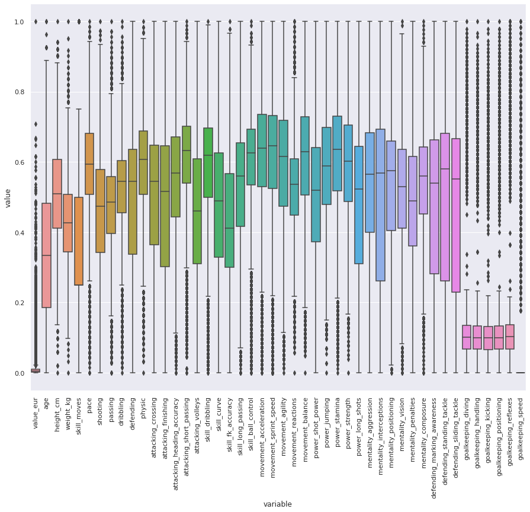

```python
import matplotlib.pyplot as plt
import seaborn
from seaborn import boxplot
melted=pd.melt(normData)
seaborn.set(rc={"figure.figsize":(15, 12)})
plt=boxplot(x='variable',y='value',data=melted)
plt.set_xticklabels(plt.get_xticklabels(),rotation=90)
plt
```

##### Outliers Approach

I'm going to take a fairly easy approach here from eyeballing the above graph.  
The first column highlights a column that is highly skewed. This probably represents a bigger problem in football altogehter where the majority of players are paid a similar amount but then start players or specific teams in top leagues where players are getting paid vastly more. These players should not be ignored from our data but because of how skewed the data is I'm going to drop this column.  
Then the same could be said for all goalkeeping stats. Most palyers are not goalkeeprs so the majority of the values are low, and all actual goalkeepers are going to look like outliers. Since this is actually a perfect way of identifying gaolkeepers these columns and all rows will be kept.  
From the greaph the majority of the rest of the data is relatively centered or within the whiskers of the box plot and as I don't want to ditch highly skilled or terrible players I'm going to keep all of these values.

```python
normData=normData.drop(columns=['value_eur'])
```

### Oversampleing

Due to the natural amount of players in each position I konw that their will be significently less goalkeepers in our data set which could possibly lead to some issues. To fix this I'm going to take a look at the distribution and add additional goalkeeper examples.

<aside style="margin-top:0px";>

[figure not shown]

</aside>

[figure not shown]

```python
print(data[['age','player_positions']].groupby(by='player_positions').count())
```

```
                   age
player_positions
0.0               2124
1.0               6366
2.0               5865
3.0               4810
```

```python
from sklearn.model_selection import train_test_split
print("Note that we have a lot less GKs so to make sure they are accounted for I am going to double up on the amount of them in the training set")
print("Total number of players: {}".format(len(data)))
normData['position']=data['player_positions']
gk=normData.loc[normData['position']==0.0]
print("Total number of GKs: {}".format(len(gk)))
normData2=pd.concat([normData,gk])
print("New number of players: {}".format(len(normData2)))
#For saving the data in Protobuf format I'll be chaning the positions to floats
X_train, X_test, y_train, y_test = train_test_split(normData2.drop(columns=['position']), normData2['position'], test_size=.15,random_state = 100)
```

```
Note that we have a lot less GKs so to make sure they are accounted for I am going to double up on the amount of them in the training set
Total number of players: 19165
Total number of GKs: 2124
New number of players: 21289
```

## Amazon Sagemaker - KNN

Sagemaker is a fully managed service that allows data scientists and developers to easily build, train, and deploy machine learning models at scale. It provides hardware that runs on AWS, built in models and automated tuning as well as Auto ML but that's a subject for another model.

[figure not shown]

```python
import os
data_dir = "/home/ec2-user/SageMaker/sageMakerDemos/Data/"
X_train.to_csv(os.path.join(data_dir,"train/features.csv"))
y_train.to_csv(os.path.join(data_dir,"train/labels.csv"))
X_test.to_csv(os.path.join(data_dir,"test/features.csv"))
y_test.to_csv(os.path.join(data_dir,"test/labels.csv"))
```

Let’s write the data to Amazon S3 in recordio-protobuf format. This allows us to use file or pipe mode when training.  
We first create an io buffer wrapping the data, next we upload it to Amazon S3. Notice that the choice of bucket and prefix should change for different users and different datasets

```python
import io
import sagemaker.amazon.common as smac
X_train=np.array(X_train).astype("float")
y_train=np.array(y_train).astype("float")
print("Types: {}, {}".format(type(X_train), type(y_train)))
print("train_features shape = ", X_train.shape)
print("train_labels shape = ", y_train.shape)

buf = io.BytesIO()
smac.write_numpy_to_dense_tensor(buf, X_train, np.array(y_train))
buf.seek(0)
```

```
Types: <class 'numpy.ndarray'>, <class 'numpy.ndarray'>
train_features shape =  (18095, 45)
train_labels shape =  (18095,)
```

```
0
```

```python
import boto3
import os
import sagemaker

bucket = sagemaker.Session().default_bucket()  # modify to your bucket name
prefix = "knn-cwright-example-2022-04-06"
key = "recordio-pb-data"

boto3.resource("s3").Bucket(bucket).Object(os.path.join(prefix, "train", key)).upload_fileobj(buf)
s3_train_data = f"s3://{bucket}/{prefix}/train/{key}"
print(f"uploaded training data location: {s3_train_data}")
```

```
uploaded training data location: s3://sagemaker-us-east-1-022761975017/knn-cwright-example-2022-04-06/train/recordio-pb-data
```

```python
X_test=np.array(X_test).astype("float")
y_test=np.array(y_test).astype("float")
print(f"test_features shape = {X_test.shape}")
print(f"test_labels shape = {y_test.shape}")

buf = io.BytesIO()
smac.write_numpy_to_dense_tensor(buf, X_test, y_test)
buf.seek(0)

boto3.resource("s3").Bucket(bucket).Object(os.path.join(prefix, "test", key)).upload_fileobj(buf)
s3_test_data = f"s3://{bucket}/{prefix}/test/{key}"
print(f"uploaded test data location: {s3_test_data}")
```

```
test_features shape = (3194, 45)
test_labels shape = (3194,)
uploaded test data location: s3://sagemaker-us-east-1-022761975017/knn-cwright-example-2022-04-06/test/recordio-pb-data
```

### Training

#### Now lets run the KNN algorithm!

[figure not shown]

K-Nearest Neighbors is a machine learning technique and algorithm that can be used for both regression and classification tasks. K-Nearest Neighbors examines the labels of a chosen number of data points surrounding a target data point, in order to make a prediction about the class that the data point falls into.  
I also considered using the K-Means algo becasue I think it could do a good job of classifying the data since we know the number of groups but for the sake of doing hyperparameter tuning with a test-accuracy I needed a supervised technique.

```python
import matplotlib.pyplot as plt

import sagemaker
from sagemaker import get_execution_role
from sagemaker.serializers import CSVSerializer
from sagemaker.deserializers import JSONDeserializer
from sagemaker.amazon.amazon_estimator import get_image_uri

######
# Name : trained_estimator_from_hyperparams
######
# Def  : Train a KNN model
######
# Args : - s3_train_data - Path to S3 training data
# Args : - hyperparams - Params for the KNN model
# Args : - output_path - S3 path where model will be saved
# Args : - s3_test_data - Optional Path to S3 training data
######
# Name : trained_estimator_from_hyperparams
def train_knn_from_hyperparams(s3_train_data, hyperparams, output_path, s3_test_data=None):
    """
    Create an Estimator from the given hyperparams, fit to training data,
    and return a deployed predictor

    """
    # set up the estimator
    knn = sagemaker.estimator.Estimator(
        get_image_uri(boto3.Session().region_name, "knn"),
        get_execution_role(),
        instance_count=1,
        instance_type="ml.m5.2xlarge",
        output_path=output_path,
        sagemaker_session=sagemaker.Session(),
    )
    knn.set_hyperparameters(**hyperparams)

    # train a model. fit_input contains the locations of the train and test data
    fit_input = {"train": s3_train_data}
    if s3_test_data is not None:
        fit_input["test"] = s3_test_data
    knn.fit(fit_input)
    return knn
```

```python
#We can revisit the hyperparameters later by using Sagemakers hyper parameter tuning jobs
hyperparams = {"feature_dim": 45, "k": 10, "sample_size": 2000, "predictor_type": "classifier"}
output_path = f"s3://{bucket}/{prefix}/default_example/output"
knn_estimator = train_knn_from_hyperparams(
    s3_train_data, hyperparams, output_path, s3_test_data=s3_test_data
)
```

```
The method get_image_uri has been renamed in sagemaker>=2.
See: https://sagemaker.readthedocs.io/en/stable/v2.html for details.
Defaulting to the only supported framework/algorithm version: 1. Ignoring framework/algorithm version: 1.
```

[output not shown]

[output cut: 8 more lines]

```
[04/09/2022 09:29:15 INFO 140267659511616] Searching index...
[04/09/2022 09:29:15 INFO 140267659511616] ...Done searching index in 0 second(s)
[2022-04-09 09:29:15.550] [tensorio] [info] epoch_stats={"data_pipeline": "/opt/ml/input/data/test", "epoch": 0, "duration": 1181, "num_examples": 1, "num_bytes": 1315928}
#metrics {"StartTime": 1649496555.430961, "EndTime": 1649496555.5624526, "Dimensions": {"Algorithm": "AWS/KNN", "Host": "algo-1", "Operation": "training", "Meta": "test_data_iter"}, "Metrics": {"Total Records Seen": {"sum": 3194.0, "count": 1, "min": 3194, "max": 3194}, "Total Batches Seen": {"sum":…
[04/09/2022 09:29:15 INFO 140267659511616] #test_score (algo-1) : ('accuracy', 0.8400125234815279)
[04/09/2022 09:29:15 INFO 140267659511616] #test_score (algo-1) : ('macro_f_1.000', 0.8443371)
[04/09/2022 09:29:15 INFO 140267659511616] #quality_metric: host=algo-1, test accuracy <score>=0.8400125234815279
[04/09/2022 09:29:15 INFO 140267659511616] #quality_metric: host=algo-1, test macro_f_1.000 <score>=0.8443371057510376
#metrics {"StartTime": 1649496555.4304945, "EndTime": 1649496555.5635831, "Dimensions": {"Algorithm": "AWS/KNN", "Host": "algo-1", "Operation": "training"}, "Metrics": {"setuptime": {"sum": 15.60664176940918, "count": 1, "min": 15.60664176940918, "max": 15.60664176940918}, "totaltime": {"sum": 1651.…
[04/09/2022 09:29:15 INFO 140267659511616 integration.py:636] worker closed

2022-04-09 09:29:33 Uploading - Uploading generated training model
2022-04-09 09:29:33 Completed - Training job completed
Training seconds: 152
Billable seconds: 152
```

### Testing

Lets deploy a prediction endpoint and use the test data to evaluate our model.

```python
import time

######
# Name : fifa_knn_predictor
######
# Def  : Make a prediction of a players position using KNN
######
# Args : - knn_estimator - Sagemaker trained knn model
# Args : - estimator_name - Name we give to our estimator
# Args : - instance_type - Hardware Sagemaker will use for predictions
# Args : - endpoint_name - Sagemaker endoint name for logging
######
# Name : trained_estimator_from_hyperparams
def fifa_knn_predictor(knn_estimator, estimator_name, instance_type, endpoint_name=None):
    knn_predictor = knn_estimator.deploy(
        initial_instance_count=1, instance_type=instance_type, endpoint_name=endpoint_name
    )
    knn_predictor.serializer = CSVSerializer()
    knn_predictor.deserializer = JSONDeserializer()
    return knn_predictor

instance_type = "ml.c4.large"
model_name = "knn_%s" % instance_type
endpoint_name = "knn-ml-c4-large-%s" % (str(time.time()).replace(".", "-"))
print("setting up the endpoint..")
predictor = fifa_knn_predictor(
    knn_estimator, model_name, instance_type, endpoint_name=endpoint_name
)
```

```
setting up the endpoint..
---------------!
```

##### Now lets test it out!

We now have an active endpoint hosted on dedicated hardware to make inference.  
To test out this model I'm going to use the starting 11 from my favourite team, Liverpool!

```python
batches = np.array_split(X_test, 100)
print(f"data split into 100 batches, of size {batches[0].shape[0]}.")

# obtain an np array with the predictions for the entire test set
start_time = time.time()
predictions = []
for batch in batches:
    result = predictor.predict(batch, initial_args={"ContentType": "text/csv"})
    cur_predictions = np.array(
        [result["predictions"][i]["predicted_label"] for i in range(len(result["predictions"]))]
    )
    predictions.append(cur_predictions)
predictions = np.concatenate(predictions)
run_time = time.time() - start_time

test_size = y_test.shape[0]
num_correct = sum(predictions == y_test)
accuracy = num_correct / float(test_size)
print("time required for predicting %d data point: %.2f seconds" % (test_size, run_time))
print("accuracy of model: %.1f%%" % (accuracy * 100))
```

```
data split into 100 batches, of size 32.
time required for predicting 3194 data point: 3.76 seconds
accuracy of model: 84.0%
```

```python
import colorama
from colorama import Fore as colour
def printRed(text):
    print(colour.RED+text)

def printGreen(text):
    print(colour.GREEN+text)

revPosDict={0.0:'Goal Keeper',1.0:'Defender',2.0:"Midfielder",3.0:"Forward"}
#Get the Liverpool starting 11
liverpool=fifa.loc[fifa['club_name']=='Liverpool'][:11]

for i in liverpool.index:
    realPos=revPosDict[normData['position'].loc[i]]
    predPos=predictor.predict(np.array(normData2.drop(columns=['position']).loc[i]).astype(float))
    predPos=revPosDict[predPos['predictions'][0]['predicted_label']]
    name=liverpool['short_name'].loc[i]
    if realPos==predPos:
        printGreen("Player {name} is a {pos} and we predicted {pred}".format(name=name,pos=realPos,pred=predPos))
    if realPos!=predPos:
        printRed("Player {name} is a {pos} and we predicted {pred}".format(name=name,pos=realPos,pred=predPos))
```

```
Player V. van Dijk is a Defender and we predicted Midfielder
Player S. Mané is a Forward and we predicted Forward
Player M. Salah is a Forward and we predicted Forward
Player Alisson is a Goal Keeper and we predicted Goal Keeper
Player A. Robertson is a Defender and we predicted Defender
Player T. Alexander-Arnold is a Defender and we predicted Defender
Player Thiago is a Midfielder and we predicted Midfielder
Player Fabinho is a Midfielder and we predicted Midfielder
Player Roberto Firmino is a Forward and we predicted Forward
Player J. Henderson is a Midfielder and we predicted Midfielder
Player J. Matip is a Defender and we predicted Defender
```

[figure not shown]

So we correctly predicted everyone on the team except for Virgil van Dijk. Some characteristics about him made the model associate him with a midfield position.

```python
res=pd.DataFrame(data=[predictions,y_test]).T
res.columns=['predicted','real']
res['correct']=res['predicted']==res['real']
res=res.groupby(by='real').mean()
res.index=['G','D','M','F']
res['correct']
```

```
G    1.000000
D    0.922996
M    0.721293
F    0.731044
Name: correct, dtype: float64
```

```python
def delete_endpoint(predictor):
    try:
        boto3.client("sagemaker").delete_endpoint(EndpointName=predictor.endpoint_name)
        print(f"Deleted {predictor.endpoint_name}")
    except:
        print(f"Already deleted: {predictor.endpoint_name}")


delete_endpoint(predictor)
```

```
Deleted knn-ml-c4-large-1649496586-1403375
```

## Hyperparameter tuning

### Set Up

```python
from sagemaker.tuner import (
    IntegerParameter,
    CategoricalParameter,
    ContinuousParameter,
    HyperparameterTuner,
)

# set up the estimator
output_path='s3://sagemaker-us-east-1-022761975017/knn-cwright-example-2022-04-06/auto-tune/output'
knn = sagemaker.estimator.Estimator(
    get_image_uri(boto3.Session().region_name, "knn"),
    get_execution_role(),
    instance_count=1,
    instance_type="ml.m5.2xlarge",
    output_path=output_path,
    sagemaker_session=sagemaker.Session(),
)

#Choose hyperparams
#Fixed
hyperparams = {"feature_dim": 45, "predictor_type": "classifier"}
knn.set_hyperparameters(**hyperparams)
#Tune-able
hyperparameter_ranges = {
    "k": IntegerParameter(5, 20),
    "sample_size": IntegerParameter(2000,20000, scaling_type='Logarithmic') #make sue to use logarithmic scale for large vals
}

#Objective we will measure on
objective_metric_name = "test:accuracy"
objective_metric_func = "Maximize"
#Max jobs to run
max_jobs=1 #Running the tuning with just a single job first to make sure we don't get any errors
#Max parallel jobs to run - note tuning uses previous results so don't do too much in parallel.
max_parallel_jobs=2
tuner = HyperparameterTuner(
    knn,
    objective_metric_name,
    hyperparameter_ranges,
    objective_type=objective_metric_func,
    max_jobs=max_jobs,
    max_parallel_jobs=max_parallel_jobs,
)
```

```
The method get_image_uri has been renamed in sagemaker>=2.
See: https://sagemaker.readthedocs.io/en/stable/v2.html for details.
Defaulting to the only supported framework/algorithm version: 1. Ignoring framework/algorithm version: 1.
```

```python
tuner.fit({"train": s3_train_data, "test": s3_test_data}, include_cls_metadata=False)
```

```
.............................................................!
```

```python
tuning_job_name = tuner._current_job_name
print('Sucessfully ran the job!')
tuner_parent_metrics = sagemaker.HyperparameterTuningJobAnalytics(tuning_job_name)
if not tuner_parent_metrics.dataframe().empty:
    df_parent = tuner_parent_metrics.dataframe().sort_values(
        ["FinalObjectiveValue"], ascending=False
    )

df_parent
```

```
Sucessfully ran the job!
```

|  | k | sample_size | TrainingJobName | TrainingJobStatus | FinalObjectiveValue | TrainingStartTime | TrainingEndTime | TrainingElapsedTimeSeconds |
| --- | --- | --- | --- | --- | --- | --- | --- | --- |
| 0 | 5.0 | 17251.0 | knn-220409-1001-001-2b5fd9eb | Completed | 0.867877 | 2022-04-09 10:03:55+00:00 | 2022-04-09 10:06:01+00:00 | 126.0 |

### Tuning

```python
print("Now lets run the job with 10 epochs")

max_jobs=10
tuner = HyperparameterTuner(
    knn,
    objective_metric_name,
    hyperparameter_ranges,
    objective_type=objective_metric_func,
    max_jobs=max_jobs,
    max_parallel_jobs=max_parallel_jobs,
)
tuner.fit({"train": s3_train_data, "test": s3_test_data}, include_cls_metadata=False)
```

[output not shown]

You can navigate to the training jobs section in Sagemaker to check up on the process. There you can see which jobs have been completed, still in progress and if any failures occurred. Additionally you can click on any of the jobs and check what parameters the job is testing out.

[figure not shown]

```python
tuning_job_name = tuner._current_job_name
tuner_parent_metrics = sagemaker.HyperparameterTuningJobAnalytics(tuning_job_name)
if not tuner_parent_metrics.dataframe().empty:
    df_parent = tuner_parent_metrics.dataframe().sort_values(
        ["FinalObjectiveValue"], ascending=False
    )
#Take a look at the job which maximized the objective
df_parent.loc[df_parent['FinalObjectiveValue']==max(df_parent['FinalObjectiveValue'])]
```

|  | k | sample_size | TrainingJobName | TrainingJobStatus | FinalObjectiveValue | TrainingStartTime | TrainingEndTime | TrainingElapsedTimeSeconds |
| --- | --- | --- | --- | --- | --- | --- | --- | --- |
| 2 | 20.0 | 19029.0 | knn-220409-1006-008-2eda39f7 | Completed | 0.876644 | 2022-04-09 10:19:13+00:00 | 2022-04-09 10:20:55+00:00 | 102.0 |
| 3 | 20.0 | 20000.0 | knn-220409-1006-007-4e6f3c73 | Completed | 0.876644 | 2022-04-09 10:19:16+00:00 | 2022-04-09 10:21:03+00:00 | 107.0 |

```python
import bokeh
import bokeh.io

bokeh.io.output_notebook()
from bokeh.plotting import figure, show
from bokeh.models import HoverTool

import pandas as pd

df_parent_objective_value = df_parent[df_parent["FinalObjectiveValue"] > -float("inf")]

p = figure(
    plot_width=900,
    plot_height=400,
    x_axis_type="datetime",
    x_axis_label="datetime",
    y_axis_label=objective_metric_name,
)
p.circle(
    source=df_parent_objective_value, x="TrainingStartTime", y="FinalObjectiveValue", color="black"
)
show(p)
```

[interactive chart not shown]

### More Predictions

```python
#Set up a predictor using the best tuning job outcome
instance_type = "ml.c4.large"
model_name = "knn-optomized%s" % instance_type
endpoint_name = "knn-optomized-ml-c4-large-%s" % (str(time.time()).replace(".", "-"))
print("setting up the endpoint..")
predictor = tuner.deploy(initial_instance_count=1,
                        instance_type=instance_type,
                        endpoint_name=endpoint_name)
```

```
setting up the endpoint..

2022-04-09 10:21:03 Starting - Preparing the instances for training
2022-04-09 10:21:03 Downloading - Downloading input data
2022-04-09 10:21:03 Training - Training image download completed. Training in progress.
2022-04-09 10:21:03 Uploading - Uploading generated training model
2022-04-09 10:21:03 Completed - Training job completed
--------------!
```

```python
#Get new predictions
batches = np.array_split(X_test, 100)
print(f"data split into 100 batches, of size {batches[0].shape[0]}.")

# obtain an np array with the predictions for the entire test set
start_time = time.time()
predictions = []
predictor.serializer = CSVSerializer()
predictor.deserializer = JSONDeserializer()

for batch in batches:
    result = predictor.predict(batch, initial_args={"ContentType": "text/csv"})
    cur_predictions = np.array(
        [result["predictions"][i]["predicted_label"] for i in range(len(result["predictions"]))]
    )
    predictions.append(cur_predictions)
predictions = np.concatenate(predictions)
run_time = time.time() - start_time

test_size = y_test.shape[0]
num_correct = sum(predictions == y_test)
accuracy = num_correct / float(test_size)
print("time required for predicting %d data point: %.2f seconds" % (test_size, run_time))
print("accuracy of model: %.1f%%" % (accuracy * 100))
```

```
data split into 100 batches, of size 32.
time required for predicting 3194 data point: 2.02 seconds
accuracy of model: 87.7%
```

```python
#Get Liverpool players
print("Now that we have a better accuracy of 87.7% lets try and predict the positions of the Liverpool team again")

for i in liverpool.index:
    realPos=revPosDict[normData['position'].loc[i]]
    predPos=predictor.predict(np.array(normData2.drop(columns=['position']).loc[i]).astype(float))
    predPos=revPosDict[predPos['predictions'][0]['predicted_label']]
    name=liverpool['short_name'].loc[i]
    if realPos==predPos:
        printGreen("Player {name} is a {pos} and we predicted {pred}".format(name=name,pos=realPos,pred=predPos))
    if realPos!=predPos:
        printRed("Player {name} is a {pos} and we predicted {pred}".format(name=name,pos=realPos,pred=predPos))
```

```
Now that we have a better accuracy of 87.7% lets try and predict the positions of the Liverpool team again
Player V. van Dijk is a Defender and we predicted Defender
Player S. Mané is a Forward and we predicted Forward
Player M. Salah is a Forward and we predicted Forward
Player Alisson is a Goal Keeper and we predicted Goal Keeper
Player A. Robertson is a Defender and we predicted Defender
Player T. Alexander-Arnold is a Defender and we predicted Defender
Player Thiago is a Midfielder and we predicted Midfielder
Player Fabinho is a Midfielder and we predicted Midfielder
Player Roberto Firmino is a Forward and we predicted Forward
Player J. Henderson is a Midfielder and we predicted Midfielder
Player J. Matip is a Defender and we predicted Defender
```

[figure not shown]

#### Nice! We got every player this time!

Lets try and plot some of these values in an effort to show the groupings that the model is creating. To this though we will need to decrease the feature space from 45 to a human readible number. Because visually it is difficult to represent all features I will perform PCA on the original data to find the components the make the biggest impact when choosing a players positions. These components are not necessarily features themselves but some vector representation of possibly multiple features.

### PCA

```python
from sklearn.decomposition import PCA
import matplotlib.pyplot as plt
from mpl_toolkits.mplot3d import Axes3D
```

```python
pca3 = PCA(n_components=3)
principalComponents = pca3.fit_transform(X_test)

principalDf = pd.DataFrame(data = principalComponents, columns = ['principal component 1', 'principal component 2', 'principal component 3'])
principalDf['position']=predictions
principalDf['label']=y_test
print("Total variance explained by PCA is: {tot}\nBreakdown:{each}".format(tot=sum(pca3.explained_variance_ratio_),each=pca3.explained_variance_ratio_))
```

```
Total variance explained by PCA is: 0.8196890427207113
Breakdown:[0.60806215 0.1378331  0.0737938 ]
```

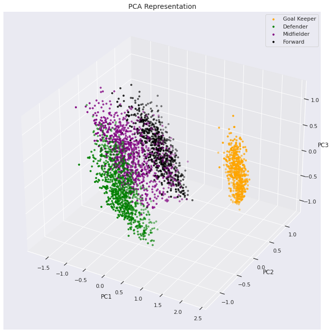

```python
fig = plt.figure(figsize=(9,9))
axes = Axes3D(fig)
axes.set_title('PCA Representation', size=14)
axes.set_xlabel('PC1')
axes.set_ylabel('PC2')
axes.set_zlabel('PC3')
posColourDict={0.0:'Orange',1.0:'Green',2.0:'Purple',3.0:'Black'}
for pos in posColourDict:
    df=principalDf.loc[principalDf['position']==pos]
    axes.scatter(df['principal component 1'],df['principal component 2'],df['principal component 3'],c=posColourDict[pos], cmap = 'prism', s=10)
axes.legend(['Goal Keeper','Defender','Midfielder','Forward'])
```

```python
def delete_endpoint(predictor):
    try:
        boto3.client("sagemaker").delete_endpoint(EndpointName=predictor.endpoint_name)
        print(f"Deleted {predictor.endpoint_name}")
    except:
        print(f"Already deleted: {predictor.endpoint_name}")


delete_endpoint(predictor)
```

## Final Review

- I cleaned up a messy data set sourced online to make it useable for ML models
- I trained a KNN model to predict players position based off their attributes
- I have shown the power of AWS's hyperparameter tuner in increasing our models accuracy
- I was able to easily leverage powerful hardware to complete training jobs in a reasonable time
- Then I switched to cheaper hardware for inference as the resource necessity was much lower
- Predicted the positions of the starting Liverpool 11 with 100% sucess!
- I was able to prove the usefulness of my model in being able to help with management when choosing their squad
- As you can see I have deleted all Endpoints after use and then shutdown this notebook to prevent further costs